# OLS - Assignment

Simon Munzert

18.09.2017

### Assignment

#### 1. The dataset “bwght” from the wooldridge package contains data on smoking behavior and infant birth weight.

##### a) Use the data to estimate the unconditional effect of cigarette consumption on child birth weight! There are two variables in the dataset that measure cigarette consumption. How are the results affected by the choice of variables here? Why? What happens if you include both variables in one model? Why?

```r
data(bwght)
?bwght
lm(bwght ~ cigs + packs, data = bwght)
```

```
##
## Call:
## lm(formula = bwght ~ cigs + packs, data = bwght)
##
## Coefficients:
## (Intercept)         cigs        packs
##    119.7719      -0.5138           NA
```

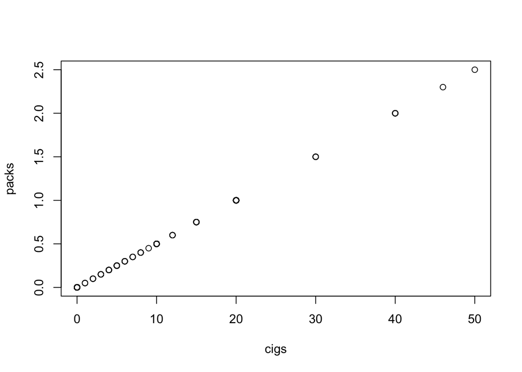

```r
with(bwght, plot(cigs, packs))
```

```r
summary(bwght$cigs / bwght$packs)
```

```
##    Min. 1st Qu.  Median    Mean 3rd Qu.    Max.    NA's
##      20      20      20      20      20      20    1176
```

##### b) The infant birth weight is measured in ounces. Create a new variable bwghtkg that measures birth weight in kilograms. How does this affect the model estimates?

```r
summary(lm(bwght ~ cigs, data = bwght))
```

```
##
## Call:
## lm(formula = bwght ~ cigs, data = bwght)
##
## Residuals:
##     Min      1Q  Median      3Q     Max
## -96.772 -11.772   0.297  13.228 151.228
##
## Coefficients:
##              Estimate Std. Error t value Pr(>|t|)
## (Intercept) 119.77190    0.57234 209.267  < 2e-16 ***
## cigs         -0.51377    0.09049  -5.678 1.66e-08 ***
## ---
## Signif. codes:  0 '***' 0.001 '**' 0.01 '*' 0.05 '.' 0.1 ' ' 1
##
## Residual standard error: 20.13 on 1386 degrees of freedom
## Multiple R-squared:  0.02273,    Adjusted R-squared:  0.02202
## F-statistic: 32.24 on 1 and 1386 DF,  p-value: 1.662e-08
```

```r
summary(lm(bwght*0.0283 ~ cigs, data = bwght))
```

```
##
## Call:
## lm(formula = bwght * 0.0283 ~ cigs, data = bwght)
##
## Residuals:
##     Min      1Q  Median      3Q     Max
## -2.7386 -0.3331  0.0084  0.3744  4.2798
##
## Coefficients:
##              Estimate Std. Error t value Pr(>|t|)
## (Intercept)  3.389545   0.016197 209.267  < 2e-16 ***
## cigs        -0.014540   0.002561  -5.678 1.66e-08 ***
## ---
## Signif. codes:  0 '***' 0.001 '**' 0.01 '*' 0.05 '.' 0.1 ' ' 1
##
## Residual standard error: 0.5696 on 1386 degrees of freedom
## Multiple R-squared:  0.02273,    Adjusted R-squared:  0.02202
## F-statistic: 32.24 on 1 and 1386 DF,  p-value: 1.662e-08
```

#### 2. Consider the “hprice1” dataset from the wooldridge package.

```r
data(hprice1)
?hprice1
```

##### a) Estimate the following model: price = beta_0 + beta_1 * sqrft + beta_2 * bdrms + u

```r
model_out <- lm(price ~ sqrft + bdrms, data = hprice1)
summary(model_out)
```

```
##
## Call:
## lm(formula = price ~ sqrft + bdrms, data = hprice1)
##
## Residuals:
##      Min       1Q   Median       3Q      Max
## -127.627  -42.876   -7.051   32.589  229.003
##
## Coefficients:
##              Estimate Std. Error t value Pr(>|t|)
## (Intercept) -19.31500   31.04662  -0.622    0.536
## sqrft         0.12844    0.01382   9.291 1.39e-14 ***
## bdrms        15.19819    9.48352   1.603    0.113
## ---
## Signif. codes:  0 '***' 0.001 '**' 0.01 '*' 0.05 '.' 0.1 ' ' 1
##
## Residual standard error: 63.04 on 85 degrees of freedom
## Multiple R-squared:  0.6319, Adjusted R-squared:  0.6233
## F-statistic: 72.96 on 2 and 85 DF,  p-value: < 2.2e-16
```

```r
coef(model_out)["bdrms"]
```

```
##    bdrms
## 15.19819
```

##### b) What is the estimated increase in price for a house with one more bedroom, holding square footage constant? And what is the estimated price for a house with 100 square meters and 4 bedrooms?

```r
coef(model_out)[1] +
coef(model_out)[2]*100*10.7639 +
coef(model_out)[3]*4
```

```
## (Intercept)
##    179.7252
```

##### c) What percentage of the variation in price is explained by square footage and number of bedrooms?

```r
summary(model_out)$r.squared
```

```
## [1] 0.6319184
```

##### d) Identify both the most overvalued and undervalued house in the sample, according to this simple model!

```r
hprice1$price_fitted <- predict(model_out)
hprice1$price_resid <- resid(model_out)
hprice1 <- arrange(hprice1, price_resid)
head(hprice1)
```

```
##     price assess bdrms lotsize sqrft colonial   lprice  lassess llotsize
## 1 111.000  202.4     4    4315  1535        1 4.709530 5.310246 8.369853
## 2 150.000  208.0     4    5218  1732        0 5.010635 5.337538 8.559870
## 3 417.500  475.5     4    8112  3733        0 6.034285 6.164367 9.001100
## 4 300.000  416.5     5    7047  2634        1 5.703783 6.031887 8.860357
## 5 180.000  221.5     3    6017  1812        1 5.192957 5.400423 8.702344
## 6 209.001  289.4     4    6400  1854        1 5.342339 5.667810 8.764053
##     lsqrft price_fitted price_resid
## 1 7.336286     238.6274  -127.62735
## 2 7.457032     263.9293  -113.92928
## 3 8.224967     520.9301  -103.43014
## 4 7.876259     394.9769   -94.97694
## 5 7.502186     259.0060   -79.00599
## 6 7.525101     279.5985   -70.59750
```

```r
tail(hprice1)
```

```
##     price assess bdrms lotsize sqrft colonial   lprice  lassess  llotsize
## 83 370.00  351.5     3    9903  2076        1 5.913503 5.862210  9.200593
## 84 471.25  482.0     5   15834  2617        1 6.155389 6.177944  9.669915
## 85 495.00  543.6     4   11966  2638        1 6.204558 6.298213  9.389825
## 86 725.00  708.6     5   31000  3662        0 6.586172 6.563291 10.341743
## 87 425.00  252.5     3    5525  1502        0 6.052089 5.531411  8.617039
## 88 713.50  655.4     5   28231  3331        1 6.570182 6.485246 10.248176
##      lsqrft price_fitted price_resid
## 83 7.638198     292.9131    77.08685
## 84 7.869784     392.7935    78.45648
## 85 7.877776     380.2925   114.70751
## 86 8.205765     527.0094   197.99064
## 87 7.314553     219.1908   205.80923
## 88 8.111028     484.4970   229.00302
```

#### 3. Demonstrate how post-treatment bias can also produce a coefficient on the treatment that is much larger than the actual treatment effect, i.e. that this type of bias can let you overestimate the effect size! Do so by performing a simple simulation in R.

```r
set.seed(42)
N <- 500
x <- rnorm(N, 0, 1)
ed <- rnorm(N, 0, .5)
d <- -x + ed  # negative relationship between d and x!
ey <- rnorm(N, 0, .5)
y <- x + d + ey

cor(cbind(y, x, d))
```

```
##            y           x          d
## y 1.00000000  0.02135604  0.3226359
## x 0.02135604  1.00000000 -0.8839895
## d 0.32263586 -0.88398947  1.0000000
```

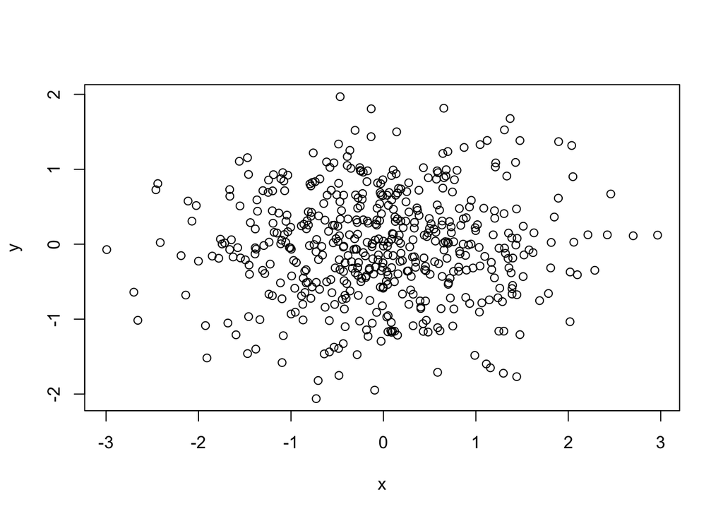

```r
plot(x, y)
```

```r
summary(lm(y ~ x)) # true effect of x on y: 0
```

```
##
## Call:
## lm(formula = y ~ x)
##
## Residuals:
##      Min       1Q   Median       3Q      Max
## -2.01888 -0.43249  0.01479  0.47621  2.00688
##
## Coefficients:
##             Estimate Std. Error t value Pr(>|t|)
## (Intercept) -0.03107    0.03169  -0.980    0.327
## x            0.01555    0.03261   0.477    0.634
##
## Residual standard error: 0.7082 on 498 degrees of freedom
## Multiple R-squared:  0.0004561,  Adjusted R-squared:  -0.001551
## F-statistic: 0.2272 on 1 and 498 DF,  p-value: 0.6338
```

```r
# model with induced post-treatment bias
summary(lm(y ~ x + d)) # estimated effect with control for d: 1
```

```
##
## Call:
## lm(formula = y ~ x + d)
##
## Residuals:
##      Min       1Q   Median       3Q      Max
## -1.44174 -0.30884  0.00087  0.31758  1.34570
##
## Coefficients:
##             Estimate Std. Error t value Pr(>|t|)
## (Intercept) -0.02012    0.02166  -0.929    0.353
## x            1.02102    0.04767  21.417   <2e-16 ***
## d            1.00099    0.04196  23.859   <2e-16 ***
## ---
## Signif. codes:  0 '***' 0.001 '**' 0.01 '*' 0.05 '.' 0.1 ' ' 1
##
## Residual standard error: 0.484 on 497 degrees of freedom
## Multiple R-squared:  0.5341, Adjusted R-squared:  0.5322
## F-statistic: 284.9 on 2 and 497 DF,  p-value: < 2.2e-16
```

#### 4. Use the data in wage1 from the wooldridge package.

```r
data(wage1)
```

##### a) Use OLS to estimate the equation “log(wage) = beta0 + beta1*educ + beta2*exper + beta3*exper^2 + u" and report the results.

```r
wage1$exper2 <- wage1$exper^2
model_out <- lm(log(wage) ~ educ + exper + exper2, data = wage1)
```

##### b) Is exper^2 significant at the 1% level?

```r
summary(model_out)
```

```
##
## Call:
## lm(formula = log(wage) ~ educ + exper + exper2, data = wage1)
##
## Residuals:
##      Min       1Q   Median       3Q      Max
## -1.96387 -0.29375 -0.04009  0.29497  1.30216
##
## Coefficients:
##               Estimate Std. Error t value Pr(>|t|)
## (Intercept)  0.1279975  0.1059323   1.208    0.227
## educ         0.0903658  0.0074680  12.100  < 2e-16 ***
## exper        0.0410089  0.0051965   7.892 1.77e-14 ***
## exper2      -0.0007136  0.0001158  -6.164 1.42e-09 ***
## ---
## Signif. codes:  0 '***' 0.001 '**' 0.01 '*' 0.05 '.' 0.1 ' ' 1
##
## Residual standard error: 0.4459 on 522 degrees of freedom
## Multiple R-squared:  0.3003, Adjusted R-squared:  0.2963
## F-statistic: 74.67 on 3 and 522 DF,  p-value: < 2.2e-16
```

##### c) Using the approximation %change(wage) = 100 * (beta2 + 2 * beta3 * change(exper)), find the approximate return to the fifth year of experience. What is the approximate return to the twentieth year of experience?

```r
100*(coef(model_out)[3] + 2*coef(model_out)[4]*5)
```

```
##    exper
## 3.387329
```

```r
100*(coef(model_out)[3] + 2*coef(model_out)[4]*20)
```

```
##    exper
## 1.246655
```

```r
dat_new <- data.frame(wage = NA, educ = 10, exper = 5, exper2 = 25)
dat_new <- data.frame(wage = NA, educ = 10, exper = 20, exper2 = 400)
predict(model_out, newdata = dat_new)
```

```
##       1
## 1.56641
```

##### d) At what value of exper does additional experience actually lower predicted log(wage)? How many people have more experience in this sample?

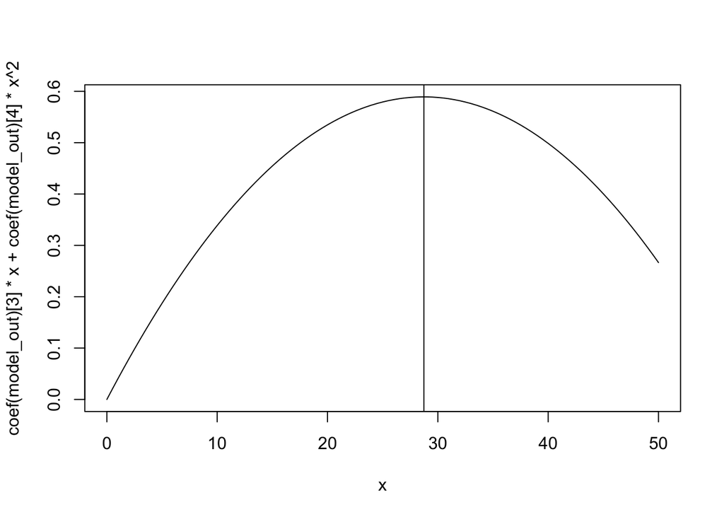

```r
curve(coef(model_out)[3]*x + coef(model_out)[4]*x^2, 0, 50)
# first derivative:
# 0.04100887 - 2*0.0007136*x
# set to zero, solve for x:
# x = 0.04100887/(2*0.0007136)
abline(v = 0.04100887/(2*0.0007136))
```

#### 5. R task: Familiarize yourself with the “broom” package, available on CRAN. The following vignette should prove useful: https://cran.r-project.org/web/packages/broom/vignettes/broom.html

##### Once you have a basic idea about what the package does, try do apply it to some of the models in this script - for instance, to plot actual vs. fitted values, extract model fit statistics, etc.